# Lab 07 - The Grammar of Networks

Arvind Venkatadri

2021-06-22

# 1 Introduction

This RMarkdown document is part of the Generic Skills Component (GSK) of the Course of the Foundation Studies Programme at Srishti Manipal Institute of Art, Design, and Technology, Bangalore India. The material is based on *A Layered Grammar of Graphics* by Hadley Wickham. The course is meant for First Year students pursuing a Degree in Art and Design.

The intent of this GSK part is to build Skill in coding in R, and also appreciate R as a way to metaphorically visualize information of various kinds, using predominantly geometric figures and structures.

All RMarkdown files combine code, text, web-images, and figures developed using code. Everything is text; code chunks are enclosed in **fences** (```)

# 2 Goals

At the end of this Lab session, we should:

- know the types and structures of `network data` and be able to work with them

- understand the basics of modern network packages in R

- be able to create network visualizations using `tidygraph`, `ggraph`( static visualizations ) and `visNetwork` (interactive visualizations)

- see directions for how the network metaphor applies in a variety of domains (e.g. biology/ecology, ideas/influence, technology, transportation, to name a few)

# 3 Pedagogical Note

The method followed will be based on [PRIMM](https://blogs.kcl.ac.uk/cser/2017/09/01/primm-a-structured-approach-to-teaching-programming/):

- **PREDICT** Inspect the code and guess at what the code might do, **write predictions**
- **RUN** the code provided and check what happens
- **INFER** what the `parameters` of the code do and **write comments to explain**. What bells and whistles can you see?
- **MODIFY** the `parameters` code provided to understand the `options` available. **Write comments** to show what you have aimed for and achieved.
- **MAKE** : take an idea/concept of your own, and graph it.

# 4 Set Up

The `setup` code **chunk** below brings into our coding session **R packages** that provide specific computational abilities and also **datasets** which we can use.

To reiterate: Packages and datasets are **not** the same thing !! Packages are (small) collections of programs. Datasets are just….information.

# 5 Graph Metaphors

Network graphs are characterized by two key terms: **nodes** and **edges**

1. `Nodes` : **Entities**
   - Metaphors: Individual People? Things? Ideas? Places? to be connected in the network.
   - Synonyms: `vertices`. Nodes have `IDs`.
2. `Edges`: **Connections**
   - Metaphors: Interactions? Relationships? Influence? Letters sent and received? Dependence? between the entities.
   - Synonyms: `links`, `ties`.

In R, we create network representations using node and edge information. *One way* in which these could be organized are:

- `Node list`: a data frame with a single column listing the node IDs found in the edge list. You can also add **attribute columns** to the data frame such as the names of the nodes or grouping variables. ( Type? Class? Family? Country? Subject? Race? )

Node Table

| ID | Node Name | Attribute? Qualities?Categories? Family? Country?Planet? |
| --- | --- | --- |
| 1 | Ned | Nursery School Teacher |
| 2 | Jaguar Paw | Main Character, Apocalypto |
| 3 | John Snow | Epidemiologist |

- `Edge list`: data frame containing two columns: **source node** and **destination node** of an `edge`. Source and Destination have `node IDs`.
- `Weighted network graph`: An edge list can also contain additional columns describing attributes of the edges such as a magnitude aspect for an edge. If the edges have a magnitude attribute the graph is considered weighted.

Edges Table

| From | To | Relationship | Weightage |
| --- | --- | --- | --- |
| 1 | 3 | Financial Dealings | 6 |
| 2 | 1 | History Lessons | 2 |
| 2 | 3 | Vaccination | 15 |

- `Layout`: A **geometric** arrangement of `nodes` and `edges`.
  - Metaphors: Location? Spacing? Distance? Coordinates? Colour? Shape? Size? Provides visual insight due to the `arrangement`.
- `Layout Algorithms` : `Method` to arranges `nodes` and `edges` with the aim of optimizing some `metric` .
  - Metaphors: Nodes are `masses` and edges are `springs`. The Layout algorithm minimizes the stretching and compressing of all springs.(BTW, are the Spring Constants K the same for all springs?…)
8. `Directed and undirected network graph`: If the distinction between source and target is meaningful, the network is **directed.** If the distinction is not meaningful, the network is **undirected**. **Directed edges** represent an ordering of nodes, like a relationship extending from one node to another, where switching the direction would change the structure of the network. **Undirected edges** are simply links between nodes where order does not matter.

Examples:

- The World Wide Web is an example of a directed network because hyperlinks connect one Web page to another, but not necessarily the other way around.
- Co-authorship networks represent examples of un-directed networks, where nodes are authors and they are connected by an edge if they have written a publication together
- When people send e-mail to each other, the distinction between the sender (source) and the recipient (target) is clearly meaningful, therefore the network is directed.
9. `Connected` and `Disconnected` graphs: If there is *some* path from *any node* to *any other node*, the Networks is said to be Connected. Else, Disconnected.

# 6 Predict/Run/Infer -1

## 6.1 Using `tidygraph` and `ggraph`

`tidygraph` and `ggraph` are modern R packages for network data. Graph Data setup and manipulation is done in tidygraph and graph visualization with ggraph.

- `tidygraph` Data -> “Network Object” in R.
- `ggraph` Network Object -> Plots using a chosen layout/algo.

Both leverage the power of **`igraph`**, which is the **Big Daddy** of all network packages. We will be using the Grey’s Anatomy dataset in our first foray into networks.

## 6.2 Step1. Read the data

```r
grey_nodes <- read_csv("data/grey_nodes.csv")
grey_edges <- read_csv("data/grey_edges.csv")


# grey_nodes <- read_delim("./Data/greys-nodes.csv", delim = ";")
# ger_edges <- read_delim("~/Downloads/grey-edges.csv",
#     delim = ";", escape_double = FALSE, trim_ws = TRUE)
grey_nodes
```

```
## # A tibble: 54 × 7
##    name               sex   race  birthyear position  season sign
##    <chr>              <chr> <chr>     <dbl> <chr>      <dbl> <chr>
##  1 Addison Montgomery F     White      1967 Attending      1 Libra
##  2 Adele Webber       F     Black      1949 Non-Staff      2 Leo
##  3 Teddy Altman       F     White      1969 Attending      6 Pisces
##  4 Amelia Shepherd    F     White      1981 Attending      7 Libra
##  5 Arizona Robbins    F     White      1976 Attending      5 Leo
##  6 Rebecca Pope       F     White      1975 Non-Staff      3 Gemini
##  7 Jackson Avery      M     Black      1981 Resident       6 Leo
##  8 Miranda Bailey     F     Black      1969 Attending      1 Virgo
##  9 Ben Warren         M     Black      1972 Other          6 Aquarius
## 10 Henry Burton       M     White      1972 Non-Staff      7 Cancer
## # ℹ 44 more rows
```

```r
grey_edges
```

```
## # A tibble: 57 × 4
##    from            to              weight type
##    <chr>           <chr>            <dbl> <chr>
##  1 Leah Murphy     Arizona Robbins      2 friends
##  2 Leah Murphy     Alex Karev           4 benefits
##  3 Lauren Boswell  Arizona Robbins      1 friends
##  4 Arizona Robbins Callie Torres        1 friends
##  5 Callie Torres   Erica Hahn           6 friends
##  6 Callie Torres   Alex Karev          12 benefits
##  7 Callie Torres   Mark Sloan           5 professional
##  8 Callie Torres   George O'Malley      2 professional
##  9 George O'Malley Izzie Stevens        3 professional
## 10 George O'Malley Meredith Grey        4 friends
## # ℹ 47 more rows
```

**Questions and Inferences #1:**

## 6.3 Step 2.Create a network object using tidygraph:

Key function:

- `tbl_graph()`: (aka “tibble graph”). Key arguments: `nodes`, `edges` and `directed`. Note this is a very versatile command and can take many input forms, such as data structures that result from other packages. Type `?tbl_graph` in the Console and see the `Usage` section.

```r
ga <- tbl_graph(nodes = grey_nodes,
                edges = grey_edges,
                directed = FALSE)
ga
```

```
## # A tbl_graph: 54 nodes and 57 edges
## #
## # An undirected simple graph with 4 components
## #
## # Node Data: 54 × 7 (active)
##    name               sex   race  birthyear position  season sign
##    <chr>              <chr> <chr>     <dbl> <chr>      <dbl> <chr>
##  1 Addison Montgomery F     White      1967 Attending      1 Libra
##  2 Adele Webber       F     Black      1949 Non-Staff      2 Leo
##  3 Teddy Altman       F     White      1969 Attending      6 Pisces
##  4 Amelia Shepherd    F     White      1981 Attending      7 Libra
##  5 Arizona Robbins    F     White      1976 Attending      5 Leo
##  6 Rebecca Pope       F     White      1975 Non-Staff      3 Gemini
##  7 Jackson Avery      M     Black      1981 Resident       6 Leo
##  8 Miranda Bailey     F     Black      1969 Attending      1 Virgo
##  9 Ben Warren         M     Black      1972 Other          6 Aquarius
## 10 Henry Burton       M     White      1972 Non-Staff      7 Cancer
## # ℹ 44 more rows
## #
## # Edge Data: 57 × 4
##    from    to weight type
##   <int> <int>  <dbl> <chr>
## 1     5    47      2 friends
## 2    21    47      4 benefits
## 3     5    46      1 friends
## # ℹ 54 more rows
```

**Questions and Inferences #2:**

**Questions and Inferences**: What information does the graph object contain? What attributes do the nodes have? What about the edges?

## 6.4 Step 3. Plot using `ggraph`

3a. Quick Plot: `autograph()` This is to check quickly is the data is imported properly and to decide upon going on to a more elaborate plotting.

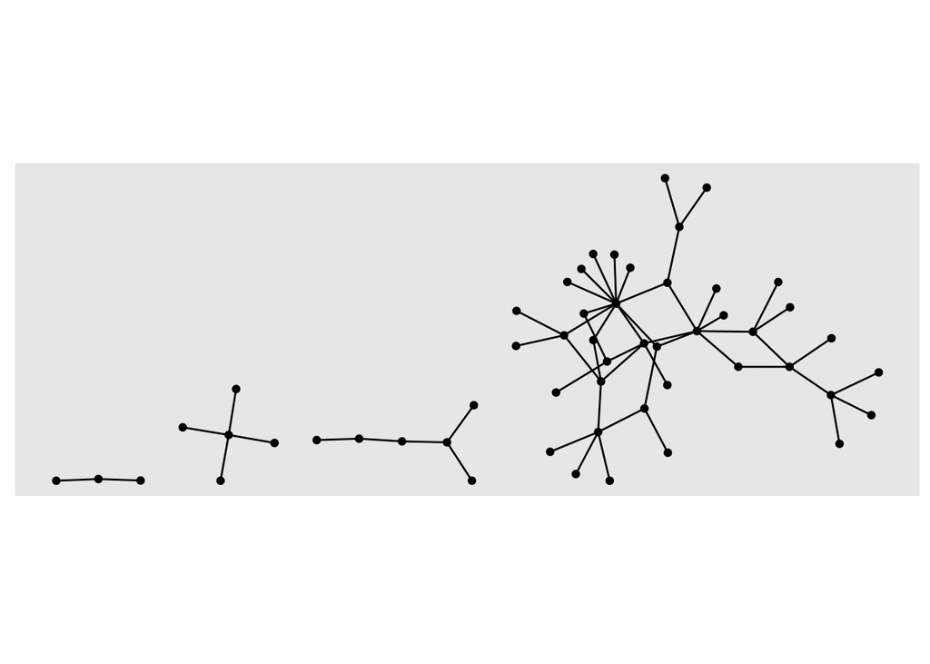

```r
autograph(ga)
```

**Questions and Inferences #3:**

**Questions and Inferences**: Describe this graph, in simple words here. Try to use some of the new domain words we have just acquired: nodes/edges, connected/disconnected, directed/undirected.

3b. More elaborate plot

Key functions:

- `ggraph(layout = "......")`: Create classic node-edge diagrams; i.e. Sets up the graph. Rather like `ggplot` for networks!

Two kinds of `geom`: one set for nodes, and another for edges

- `geom_node_point(aes(.....))`: Draws node as “points”. Alternatives are `circle / arc_bar / tile / voronoi`. Remember the `geom`s that we have seen before in Grammar of Graphics!
- `geom_edge_link(aes(.....))`: Draws edges as “links”. Alternatives are `arc / bend / elbow / hive / loop / parallel / diagonal / point / span /tile`.
- `geom_node_text(aes(label = ......), repel = TRUE)`: Adds text labels (non-overlapping). Alternatives are `label /...`
- `labs(title = "....", subtitle = "....", caption = "....")`: Change main titles, axis labels and legend titles. We know this from our work with `ggplot`.

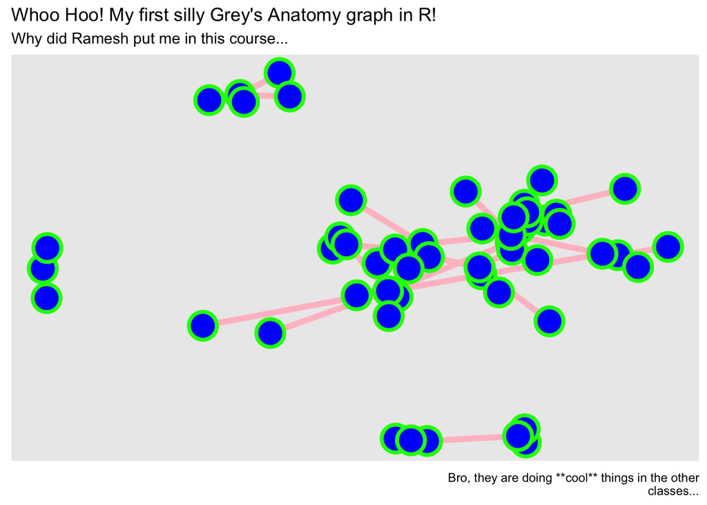

```r
# Write Comments next to each line
# About what that line does for the overall graph

ggraph(graph = ga,  layout = "kk") +
  #

  geom_edge_link(width = 2, color = "pink") +
  #

  geom_node_point(
    shape = 21,
    size = 8,
    fill = "blue",
    color = "green",
    stroke = 2
  ) +
  #

  labs(title = "Whoo Hoo! My first silly Grey's Anatomy graph in R!",
       subtitle = "Why did Ramesh put me in this course...",
       caption = "Bro, they are doing **cool** things in the other
       classes...")
```

**Questions and Inferences #3:**

**Questions and Inferences**: What parameters have been changed here, compared to the earlier graph? Where do you see these changes in the code above?

Let us **Play** with this graph and see if we can make some small changes. Colour? Fill? Width? Size? Stroke? Labs? Of course!

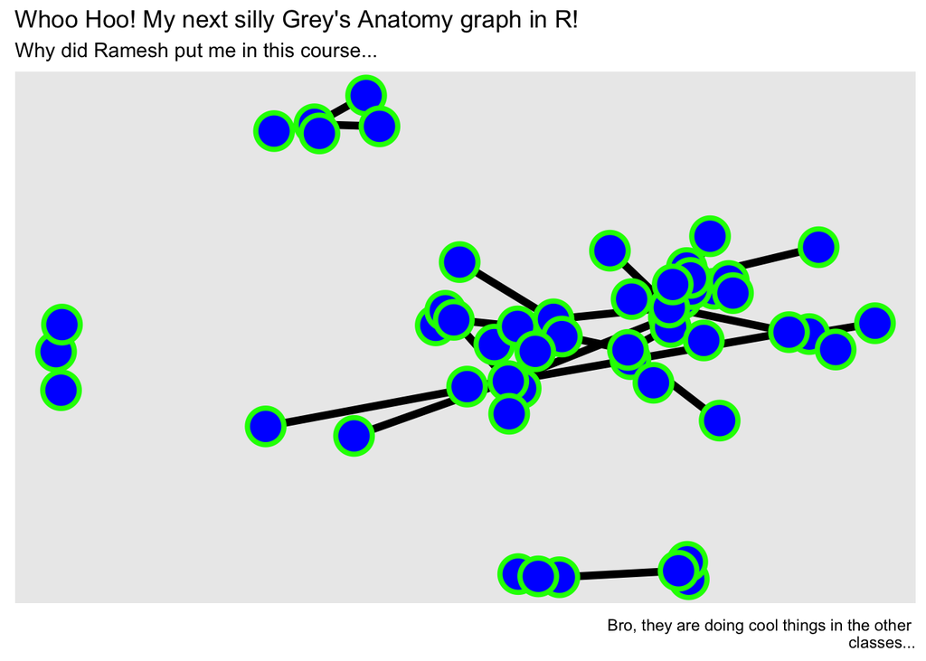

```r
# Change the parameters in each of the commands here to new ones
# Use fixed values for colours or sizes...etc.

ggraph(graph = ga,  layout = "kk") +
  geom_edge_link(width = 2) +
  geom_node_point(shape = 21, size = 8,
                  fill = "blue",
                  color = "green",
                  stroke = 2) +
  labs(title = "Whoo Hoo! My next silly Grey's Anatomy graph in R!",
       subtitle = "Why did Ramesh put me in this course...",
       caption = "Bro, they are doing cool things in the other
       classes...")
```

**Questions and Inferences #4:**

**Questions and Inferences**: What did the `shape` parameter achieve? What are the possibilities with `shape`? How about including `alpha`?

3c. Aesthetic Mapping from Node and Edge attribute columns

Up to now, we have **assigned** *specific numbers* to geometric aesthetics such as shape and size. Now we are ready ( maybe ?) change the meaning and significance of the entire graph and each element within it, and use **aesthetics / metaphoric mappings** to achieve new meanings or insights. Let us try using `aes()` inside each `geom` to map a `variable` to a geometric aspect.

Don’t try to use more than 2 aesthetic mappings simultaneously!!

The node elements we can tweak are:

- Types of Nodes: `geom_node_****()`
- Node Parameters: inside `geom_node_****(aes(...............))`  
  -`aes(alpha = node-variable)` : opacity; a value between 0 and 1  
  -`aes(shape = node-variable)` : node shape  
  -`aes(colour = node-variable)` : node colour  
  -`aes(fill = node-variable)` : fill colour for node  
  -`aes(size = node-variable)` : size of node

The edge elements we can tweak are:

- Type of Edges” `geom_edge_****()`
- Edge Parameters: inside `geom_edge_****(aes(...............))`  
  -`aes(colour = edge-variable)` : colour of the edge  
  -`aes(width = edge-variable)` : width of the edge  
  -`aes(label = some_variable)` : labels for the edge

Type `?geom_node_point` and `?geom-edge_link` in your Console for more information.

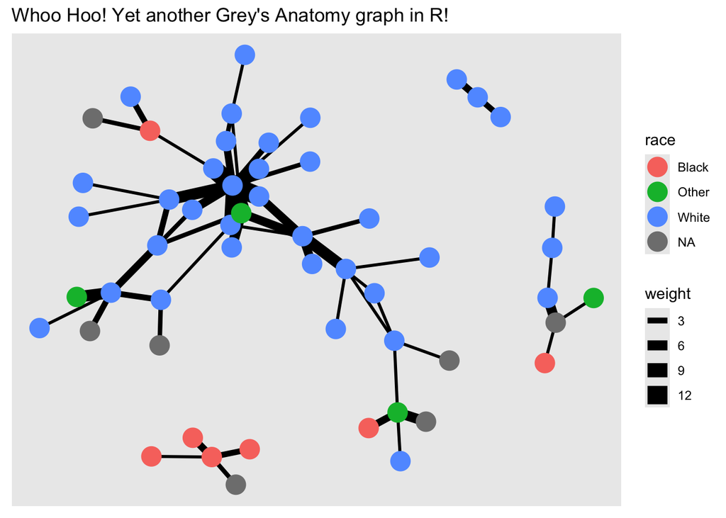

```r
ggraph(graph = ga, layout = "fr") +
  geom_edge_link0(aes(width = weight)) + # add mapping here

  geom_node_point(aes(color = race), size = 6) + # add mapping here

  # geom_node_label(aes(label = name), # modify this mapping
  #                 repel = TRUE, max.overlaps = 20,
  #                 alpha = 0.6,
  #                 size = 3) +

  labs(title = "Whoo Hoo! Yet another Grey's Anatomy graph in R!")
```

**Questions and Inferences #5:**

**Questions and Inferences**: Describe some of the changes here. What types of edges worked? Which variables were you able to use for nodes and edges and how? What did not work with either of the two?

# 7 Predict/Reuse/Infer-2

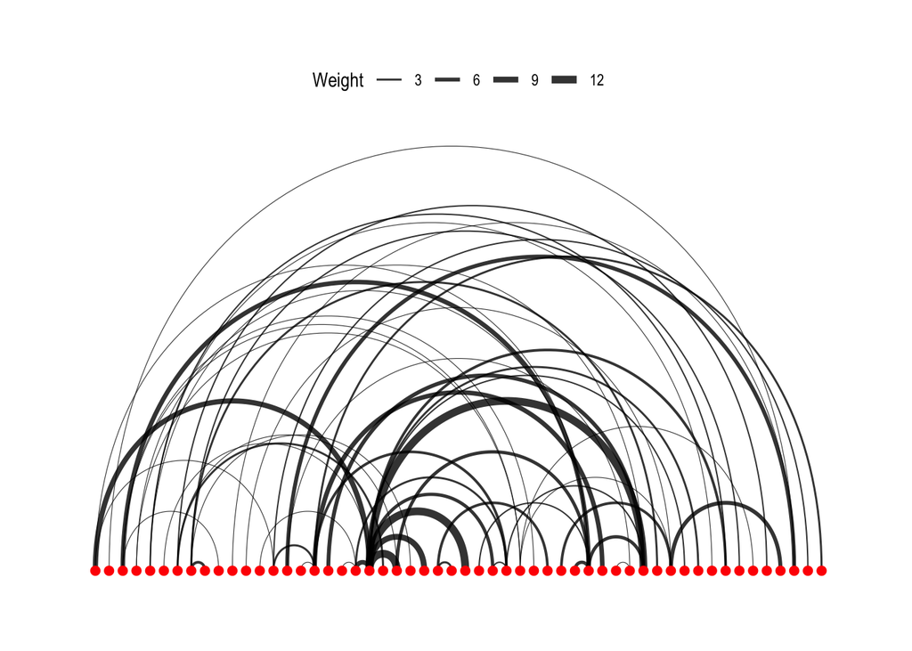

```r
# Arc diagram
ggraph(ga, layout = "linear") +
  geom_edge_arc(aes(width = weight), alpha = 0.8) +
  scale_edge_width(range = c(0.2, 2)) +
  geom_node_point(size = 2, colour = "red") +
  labs(edge_width = "Weight") +
  theme_graph()+
  theme(legend.position = "top")
```

**Questions and Inferences #6:**

**Questions and Inferences**: How does this graph look “metaphorically” different? Do you see a difference in the relationships between people here? Why?

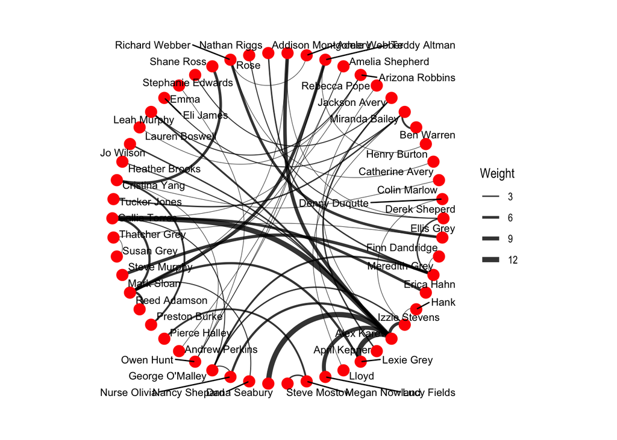

```r
# Coord diagram, circular
ggraph(ga, layout = "linear", circular = TRUE) +
  geom_edge_arc(aes(width = weight), alpha = 0.8) +
  scale_edge_width(range = c(0.2, 2)) +
  geom_node_point(size = 4,colour = "red") +
  geom_node_text(aes(label = name),repel = TRUE, size = 3,
                 max.overlaps = 20) +
  labs(edge_width = "Weight") +
  theme_graph()+
  theme(legend.position = "right",
        aspect.ratio = 1)
```

**Questions and Inferences #7:**

**Questions and Inferences**: How does this graph look “metaphorically” different? Do you see a difference in the relationships between people here? Why?

# 8 Hierarchical layouts

These provide for some alternative metaphorical views of networks. Note that not all layouts are possible for all datasets!!

```r
# setting theme_graph
set_graph_style()

# This dataset contains the graph that describes the class
# hierarchy for the Flare visualization library.
# Type ?flare in your Console
head(flare$vertices)
```

```
##                                           name size             shortName
## 1 flare.analytics.cluster.AgglomerativeCluster 3938  AgglomerativeCluster
## 2   flare.analytics.cluster.CommunityStructure 3812    CommunityStructure
## 3  flare.analytics.cluster.HierarchicalCluster 6714   HierarchicalCluster
## 4            flare.analytics.cluster.MergeEdge  743             MergeEdge
## 5  flare.analytics.graph.BetweennessCentrality 3534 BetweennessCentrality
## 6           flare.analytics.graph.LinkDistance 5731          LinkDistance
```

```r
head(flare$edges)
```

```
##                      from                                           to
## 1 flare.analytics.cluster flare.analytics.cluster.AgglomerativeCluster
## 2 flare.analytics.cluster   flare.analytics.cluster.CommunityStructure
## 3 flare.analytics.cluster  flare.analytics.cluster.HierarchicalCluster
## 4 flare.analytics.cluster            flare.analytics.cluster.MergeEdge
## 5   flare.analytics.graph  flare.analytics.graph.BetweennessCentrality
## 6   flare.analytics.graph           flare.analytics.graph.LinkDistance
```

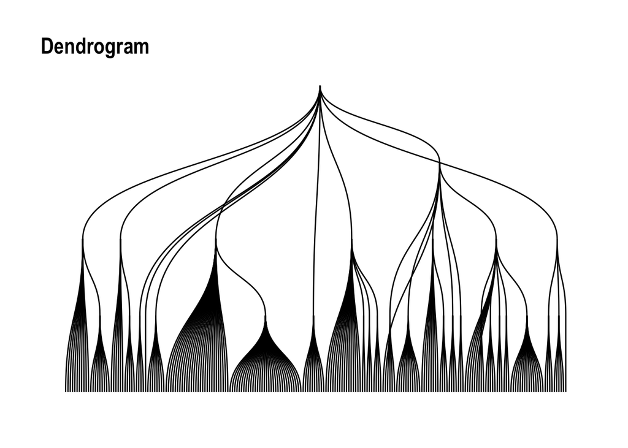

```r
# flare class hierarchy
graph = tbl_graph(edges = flare$edges, nodes = flare$vertices)

# dendrogram
ggraph(graph, layout = "dendrogram") +
  geom_edge_diagonal() +
  labs(title = "Dendrogram")
```

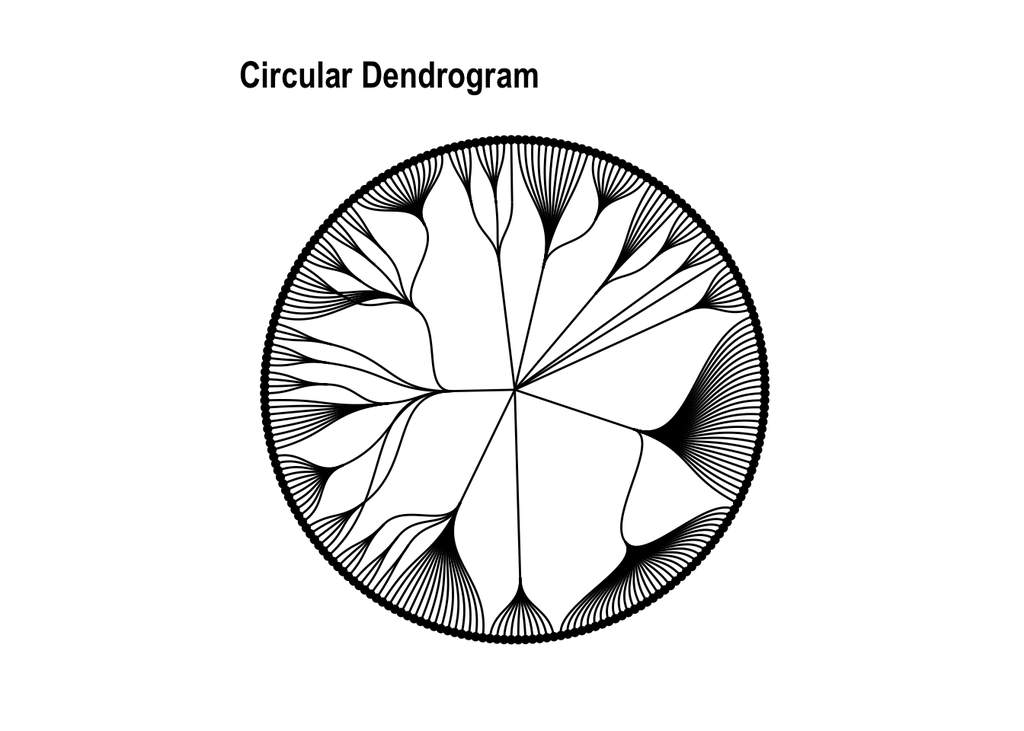

```r
# circular dendrogram
ggraph(graph, layout = "dendrogram", circular = TRUE) +
  geom_edge_diagonal() +
  geom_node_point(aes(filter = leaf)) +
  coord_fixed()+
  labs(title = "Circular Dendrogram")
```

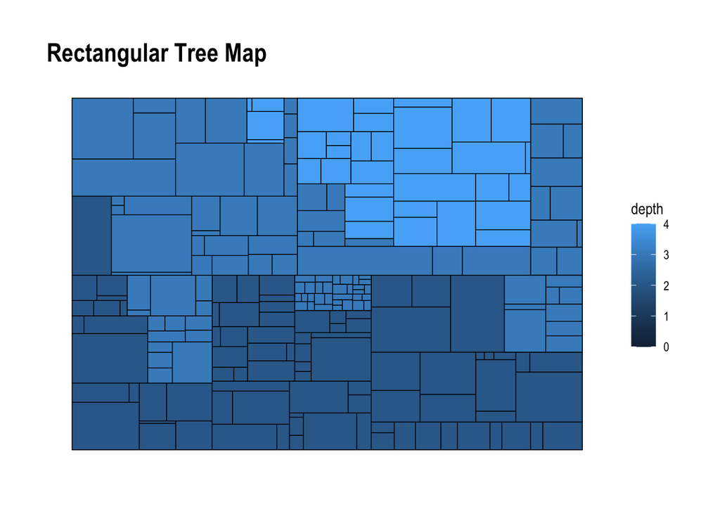

```r
# rectangular tree map
ggraph(graph, layout = "treemap", weight = size) +
  geom_node_tile(aes(fill = depth), size = 0.25) +
  labs(title = "Rectangular Tree Map")
```

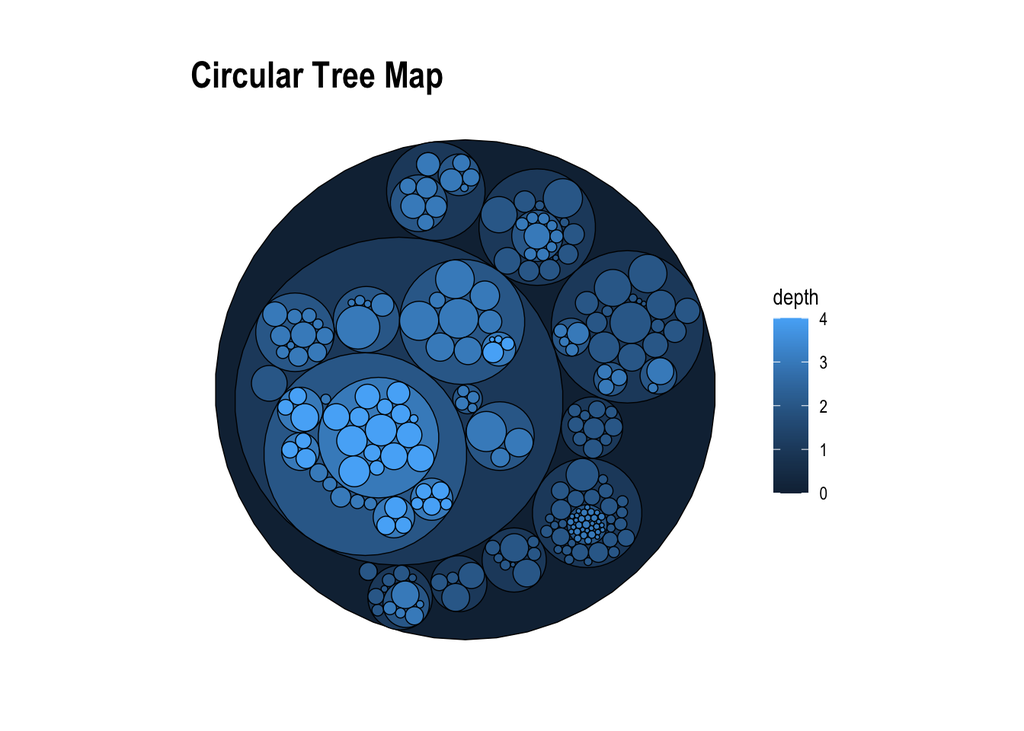

```r
# circular tree map
ggraph(graph, layout = "circlepack", weight = size) +
  geom_node_circle(aes(fill = depth), size = 0.25, n = 50) +
  coord_fixed() +
  labs(title = "Circular Tree Map")
```

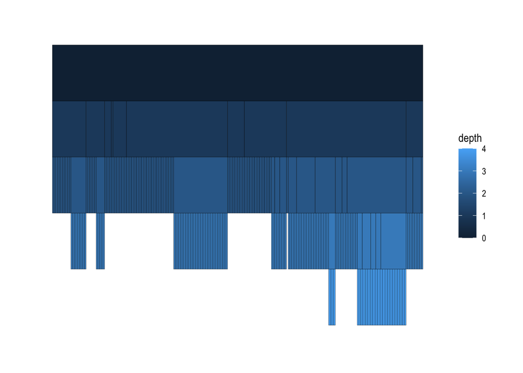

```r
# icicle
ggraph(graph, layout = "partition") +
  geom_node_tile(aes(y = -y, fill = depth))
```

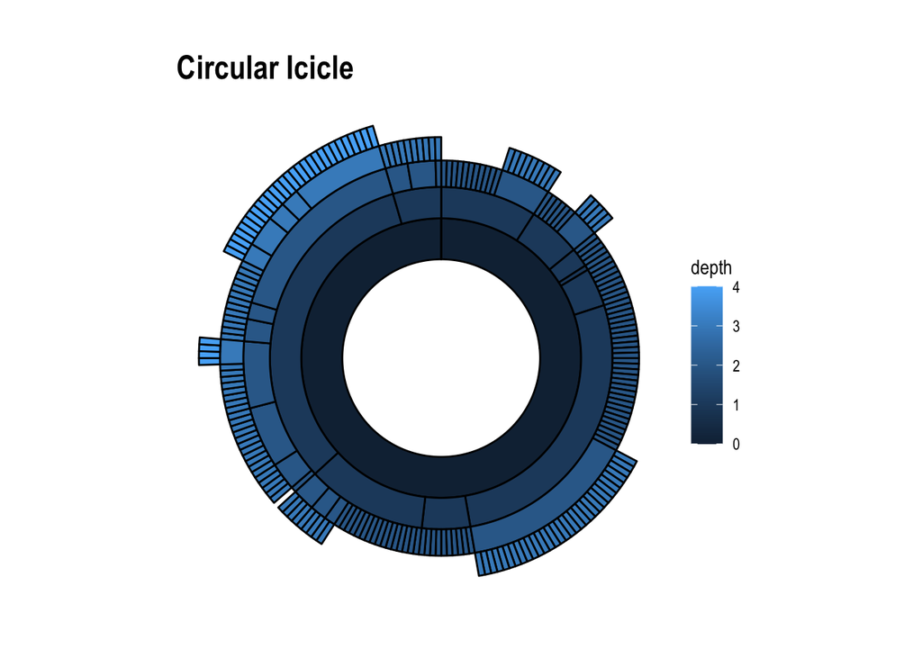

```r
# sunburst (circular icicle)
ggraph(graph, layout = "partition", circular = TRUE) +
  geom_node_arc_bar(aes(fill = depth)) +
  coord_fixed() +
  labs(title = "Circular Icicle")
```

**Questions and Inferences #8:**

**Questions and Inferences**: How do graphs look “metaphorically” different? Do they reveal different aspects of the group? How?

# 9 Faceting

Faceting allows to create sub-plots according to the values of a qualitative attribute on nodes or edges.

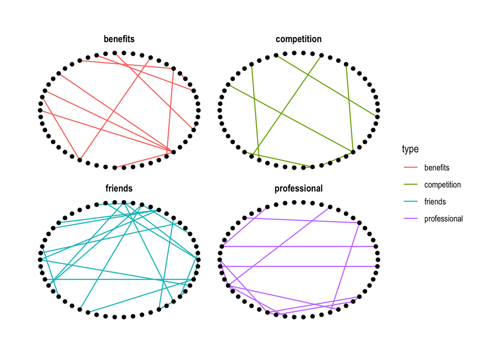

```r
# setting theme_graph
set_graph_style()


# facet edges by type
ggraph(ga,layout = "linear", circular = TRUE) +
  geom_edge_link(aes(color = type)) +
  geom_node_point() +
  facet_edges(~ type)
```

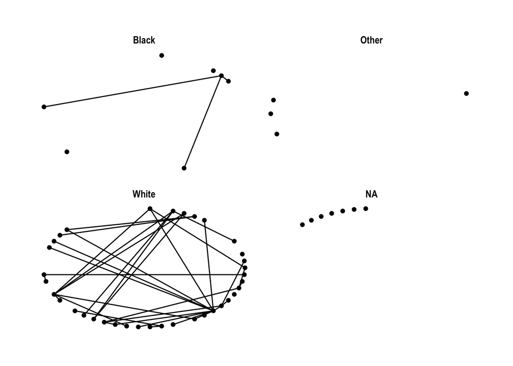

```r
# facet nodes by sex
ggraph(ga,layout = "linear", circular = TRUE) +
  geom_edge_link() +
  geom_node_point() +
  facet_nodes(~race)
```

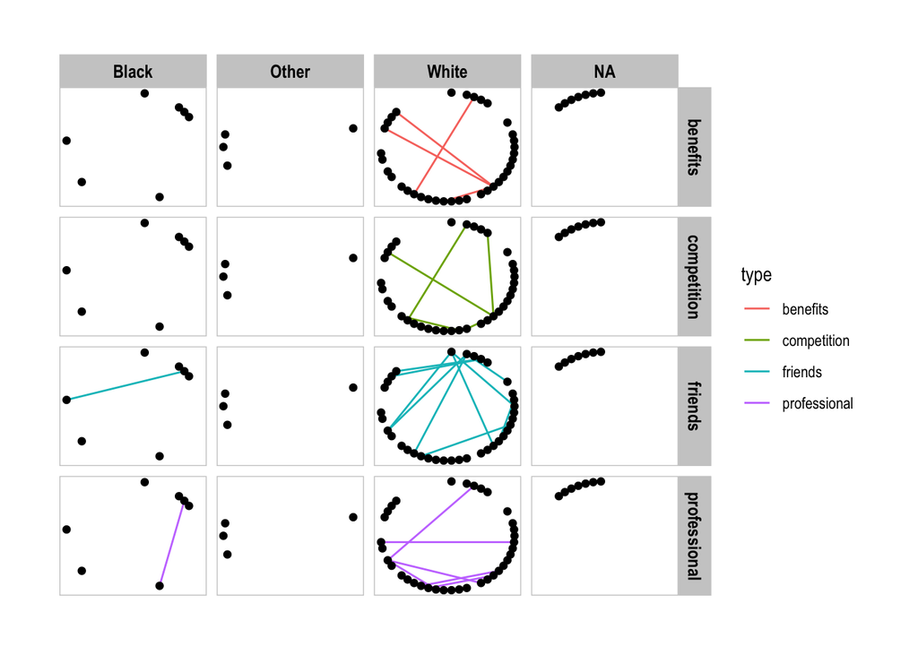

```r
# facet both nodes and edges
ggraph(ga,layout = "linear", circular = TRUE) +
  geom_edge_link(aes(color = type)) +
  geom_node_point() +
  facet_graph(type ~ race) +
  th_foreground(border = TRUE)
```

**Questions and Inferences #9:**

**Questions and Inferences**: Does splitting up the main graph into subnetworks give you more insight? Describe some of these.

# 10 Network analysis with tidygraph

The data frame graph representation can be easily augmented with **metrics** or **statistics** computed on the graph. Remember how we computed `counts` with the penguin dataset in Grammar of Graphics.

Before computing a metric on nodes or edges use the `activate()` function to activate either node or edge data frames. Use `dplyr` **verbs** (`filter, arrange, mutate`) to achieve your computation in the proper way.

## 10.1 Network Centrality

Centrality is a an “ill-defined” metric of **node and edge importance** in a network. It is therefore calculated in many ways. Type `?centrality` in your Console.

Standards

Let’s add a few columns to the nodes and edges based on network centrality measures:

```r
ga %>%
  activate(nodes) %>%

  # Most connections?
  mutate(degree = centrality_degree(mode = c("in"))) %>%
  filter(degree > 0) %>%

  activate(edges) %>%
  # "Busiest" edge?
  mutate(betweenness = centrality_edge_betweenness())
```

```
## # A tbl_graph: 54 nodes and 57 edges
## #
## # An undirected simple graph with 4 components
## #
## # Edge Data: 57 × 5 (active)
##     from    to weight type         betweenness
##    <int> <int>  <dbl> <chr>              <dbl>
##  1     5    47      2 friends             20.3
##  2    21    47      4 benefits            44.7
##  3     5    46      1 friends             39
##  4     5    41      1 friends             66.3
##  5    18    41      6 friends             39
##  6    21    41     12 benefits            91.5
##  7    37    41      5 professional       164.
##  8    31    41      2 professional        98.8
##  9    20    31      3 professional        47.2
## 10    17    31      4 friends            102.
## # ℹ 47 more rows
## #
## # Node Data: 54 × 8
##   name               sex   race  birthyear position  season sign   degree
##   <chr>              <chr> <chr>     <dbl> <chr>      <dbl> <chr>   <dbl>
## 1 Addison Montgomery F     White      1967 Attending      1 Libra       3
## 2 Adele Webber       F     Black      1949 Non-Staff      2 Leo         1
## 3 Teddy Altman       F     White      1969 Attending      6 Pisces      4
## # ℹ 51 more rows
```

Packages `tidygraph` and `ggraph` can be pipelined to perform analysis and visualization tasks in one go.

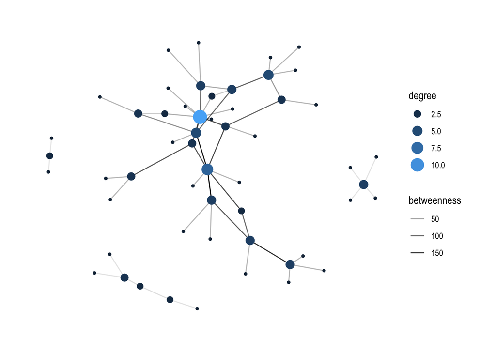

```r
# setting theme_graph
set_graph_style()

ga %>%
  activate(nodes) %>%

  # Who has the most connections?
  mutate(degree = centrality_degree()) %>%

  activate(edges) %>%
  # Who is the go-through person?
  mutate(betweenness = centrality_edge_betweenness()) %>%

  # Now to continue with plotting
  ggraph(layout = "nicely") +
  geom_edge_link(aes(alpha = betweenness)) +
  geom_node_point(aes(size = degree, colour = degree)) +

  # discrete colour legend
  scale_color_gradient(guide = "legend")
```

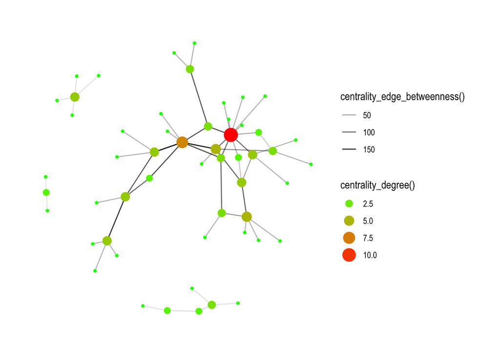

```r
# or even less typing
  ggraph(ga,layout = "nicely") +
  geom_edge_link(aes(alpha = centrality_edge_betweenness())) +
  geom_node_point(aes(colour = centrality_degree(),
                      size = centrality_degree())) +
  scale_color_gradient(guide = "legend",
                       low = "green",
                       high = "red")
```

**Questions and Inferences #10:**

**Questions and Inferences**: How do the Centrality Measures show up in the graph? Would you “agree” with the way we have done it? Try to modify the aesthetics by copy-pasting this chunk below and see how you can make an alternative representation.

## 10.2 Analyse and visualize network: communities

Who is close to whom? Which are the groups you can see?

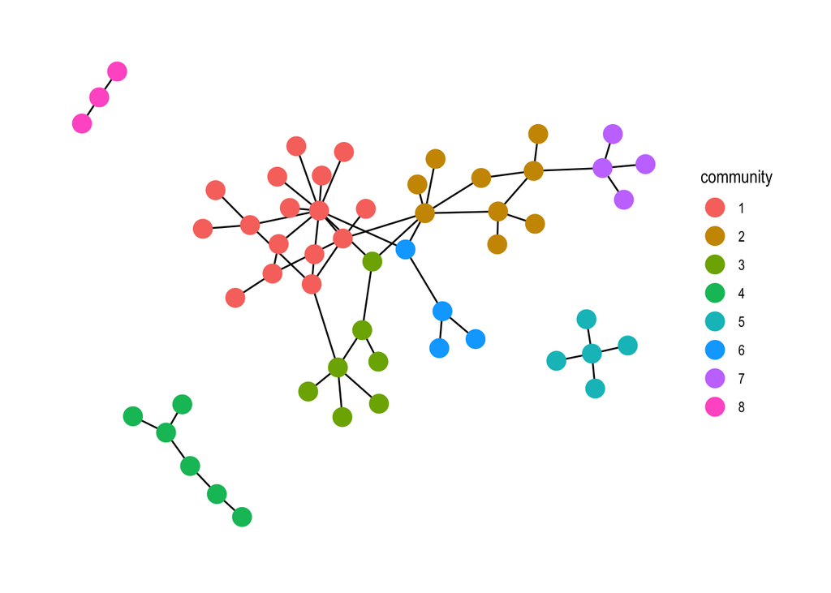

```r
# setting theme_graph
set_graph_style()


# visualize communities of nodes
ga %>%
  activate(nodes) %>%
  mutate(community = as.factor(group_louvain())) %>%
  ggraph(layout = "graphopt") +
  geom_edge_link() +
  geom_node_point(aes(color = community), size = 5)
```

**Questions and Inferences #11:**

**Questions and Inferences**: Is the Community depiction clear? How would you do it, with which aesthetic? Copy Paste this chunk below and try.

# 11 Interactive Graphs with `visNetwork`

Exploring the `VisNetwork` package. Make graphs wiggle and shake using `tidy` commands! The package implements interactivity using the physical metaphor of weights and springs we discussed earlier.

```r
library(visNetwork)

# Prepare the data for plotting by visNetwork
grey_nodes
```

```
## # A tibble: 54 × 7
##    name               sex   race  birthyear position  season sign
##    <chr>              <chr> <chr>     <dbl> <chr>      <dbl> <chr>
##  1 Addison Montgomery F     White      1967 Attending      1 Libra
##  2 Adele Webber       F     Black      1949 Non-Staff      2 Leo
##  3 Teddy Altman       F     White      1969 Attending      6 Pisces
##  4 Amelia Shepherd    F     White      1981 Attending      7 Libra
##  5 Arizona Robbins    F     White      1976 Attending      5 Leo
##  6 Rebecca Pope       F     White      1975 Non-Staff      3 Gemini
##  7 Jackson Avery      M     Black      1981 Resident       6 Leo
##  8 Miranda Bailey     F     Black      1969 Attending      1 Virgo
##  9 Ben Warren         M     Black      1972 Other          6 Aquarius
## 10 Henry Burton       M     White      1972 Non-Staff      7 Cancer
## # ℹ 44 more rows
```

```r
grey_edges
```

```
## # A tibble: 57 × 4
##    from            to              weight type
##    <chr>           <chr>            <dbl> <chr>
##  1 Leah Murphy     Arizona Robbins      2 friends
##  2 Leah Murphy     Alex Karev           4 benefits
##  3 Lauren Boswell  Arizona Robbins      1 friends
##  4 Arizona Robbins Callie Torres        1 friends
##  5 Callie Torres   Erica Hahn           6 friends
##  6 Callie Torres   Alex Karev          12 benefits
##  7 Callie Torres   Mark Sloan           5 professional
##  8 Callie Torres   George O'Malley      2 professional
##  9 George O'Malley Izzie Stevens        3 professional
## 10 George O'Malley Meredith Grey        4 friends
## # ℹ 47 more rows
```

```r
# Relabel greys anatomy nodes and edges for VisNetwork
grey_nodes_vis <- grey_nodes %>%
  rowid_to_column(var = "id") %>%
  rename("label" = name) %>%
  mutate(sex = case_when(sex == "F" ~ "Female",
                         sex == "M" ~ "Male")) %>%
  replace_na(., list(sex = "Transgender?")) %>%
  rename("group" = sex)
grey_nodes_vis
```

```
## # A tibble: 54 × 8
##       id label              group  race  birthyear position  season sign
##    <int> <chr>              <chr>  <chr>     <dbl> <chr>      <dbl> <chr>
##  1     1 Addison Montgomery Female White      1967 Attending      1 Libra
##  2     2 Adele Webber       Female Black      1949 Non-Staff      2 Leo
##  3     3 Teddy Altman       Female White      1969 Attending      6 Pisces
##  4     4 Amelia Shepherd    Female White      1981 Attending      7 Libra
##  5     5 Arizona Robbins    Female White      1976 Attending      5 Leo
##  6     6 Rebecca Pope       Female White      1975 Non-Staff      3 Gemini
##  7     7 Jackson Avery      Male   Black      1981 Resident       6 Leo
##  8     8 Miranda Bailey     Female Black      1969 Attending      1 Virgo
##  9     9 Ben Warren         Male   Black      1972 Other          6 Aquarius
## 10    10 Henry Burton       Male   White      1972 Non-Staff      7 Cancer
## # ℹ 44 more rows
```

```r
grey_edges_vis <- grey_edges %>%
  select(from, to) %>%
  left_join(., grey_nodes_vis,
            by = c("from" = "label")) %>%
  left_join(., grey_nodes_vis,
            by = c("to" = "label")) %>%
  select("from"= id.x, "to" = id.y)
grey_edges_vis
```

```
## # A tibble: 57 × 2
##     from    to
##    <int> <int>
##  1    47     5
##  2    47    21
##  3    46     5
##  4     5    41
##  5    41    18
##  6    41    21
##  7    41    37
##  8    41    31
##  9    31    20
## 10    31    17
## # ℹ 47 more rows
```

Using [fontawesome icons](https://fontawesome.com/v6.0/icons)

```r
grey_nodes_vis %>%

  visNetwork(nodes = ., edges = grey_edges_vis) %>%
  visNodes(font = list(size = 40)) %>%

  # Colour and icons for each of the gender-groups
  visGroups(groupname = "Female", shape = "icon",
            icon = list(code = "f182", size = 75, color = "tomato"),
            shadow = list(enabled = TRUE)) %>%

  visGroups(groupname = "Male", shape = "icon",
            icon = list(code = "f183", size = 75, color = "slateblue"),
            shadow = list(enabled = TRUE)) %>%

  visGroups(groupname = "Transgender?", shape = "icon",
            icon = list(code = "f22c", size = 75, color = "fuchsia"),
            shadow = list(enabled = TRUE)) %>%

  #visLegend() %>%
  #Add the fontawesome icons!!
  addFontAwesome() %>%

  # Add Interaction Controls
  visInteraction(navigationButtons = TRUE,
                 hover = TRUE,
                 selectConnectedEdges = TRUE,
                 hoverConnectedEdges = TRUE,
                 zoomView = TRUE)
```

[interactive chart not shown]

There is another family of icons available in visNetwork, called [`ionicons`](https://unpkg.com/ionicons@5.5.2/dist/cheatsheet.html). Let’s see how they look:

```r
grey_nodes_vis %>%

  visNetwork(nodes = ., edges = grey_edges_vis,) %>%
  visLayout(randomSeed = 12345) %>%
  visNodes(font = list(size = 50)) %>%
  visEdges(color = "green") %>%
  visGroups(
    groupname = "Female",
    shape = "icon",
    icon = list(
      face = 'Ionicons',
      code = "f25d",
      color = "fuchsia",
      size = 125
    )
  ) %>%

  visGroups(
    groupname = "Male",
    shape = "icon",
    icon = list(
      face = 'Ionicons',
      code = "f202",
      color = "green",
      size = 125
    )
  ) %>%

  visGroups(
    groupname = "Transgender?",
    shape = "icon",
    icon = list(
      face = 'Ionicons',
      code = "f233",
      color = "dodgerblue",
      size = 125
    )
  ) %>%
  visLegend() %>%
  addIonicons() %>%
  visInteraction(
    navigationButtons = TRUE,
    hover = TRUE,
    selectConnectedEdges = TRUE,
    hoverConnectedEdges = TRUE,
    zoomView = TRUE
  )
```

[interactive chart not shown]

Some idea of interactivity and controls with `visNetwork`:

```r
library(visNetwork)
# let's look again at the data
starwars_nodes <- read_csv("./Data/star-wars-network-nodes.csv")
starwars_edges <- read_csv("./Data/star-wars-network-edges.csv")
# We need to rename starwars nodes dataframe and edge dataframe columns for visNetwork
starwars_nodes_vis <-
  starwars_nodes %>%
  rename("label" = name)

# Convert from and to columns to **node ids**
starwars_edges_vis <-
  starwars_edges %>%

  # Matching Source <- Source Node id ("id.x")
  left_join(., starwars_nodes_vis, by = c("source" = "label")) %>%

  # Matching Target <- Target Node id ("id.y")
  left_join(., starwars_nodes_vis, by = c("target" = "label")) %>%

# Select "id.x" and "id.y" ONLY
# Rename them as "from" and "to"
# keep "weight" column for aesthetics of edges
  select("from" = id.x, "to" = id.y, "value" = weight)

# Check everything once
starwars_nodes_vis
```

```
## # A tibble: 22 × 2
##    label          id
##    <chr>       <dbl>
##  1 R2-D2           0
##  2 CHEWBACCA       1
##  3 C-3PO           2
##  4 LUKE            3
##  5 DARTH VADER     4
##  6 CAMIE           5
##  7 BIGGS           6
##  8 LEIA            7
##  9 BERU            8
## 10 OWEN            9
## # ℹ 12 more rows
```

```r
starwars_edges_vis
```

```
## # A tibble: 60 × 3
##     from    to value
##    <dbl> <dbl> <dbl>
##  1     2     0    17
##  2     3     0    13
##  3    10     0     6
##  4     7     0     5
##  5    13     0     5
##  6     1     0     3
##  7    16     0     1
##  8     1    10     7
##  9     2     1     5
## 10     1     3    16
## # ℹ 50 more rows
```

Ok, let’s make things move and shake!!

```r
visNetwork(nodes = starwars_nodes_vis,
           edges = starwars_edges_vis) %>%
  visNodes(font = list(size = 30), shape = "icon",
           icon = list(code = "f1e3", size = 75)) %>%
  addFontAwesome() %>%
  visEdges(color = "red")
```

[interactive chart not shown]

```r
visNetwork(nodes = starwars_nodes_vis,
           edges = starwars_edges_vis) %>%
  visNodes(font = list(size = 30)) %>%
  visEdges(color = "red")
```

[interactive chart not shown]

# 12 Your Assignments:

## 12.1 Make-1 : With a ready made dataset

Step 1. Fire up a *new* RMarkdown. Write your name, file_name and date.

Step 2. Take **any one** of the “Make1-Datasets” datasets decribed below.

Step 3. RMarkdown contents:

- Introduce / Inspect in R your data and describe
- Introduce your Purpose
- Create graph objects.
- Write comments in the code
- Write narrative in text with sections, bold ,italic etc.

Step 4. Knit before you submit. Submit only your knittable `.Rmd` file.

## 12.2 Make1 - Datasets:

1. Airline Data:
- Start with this bit of code in your second chunk, after `set up`

```r
airline_nodes <- read_csv("./Data/AIRLINES-NODES.csv") %>% mutate(Id = Id + 1)
airline_edges <- read_csv("./Data/AIRLINES-EDGES.csv") %>%
mutate(Source = Source + 1, Target = Target + 1)
```

2. The Famous Zachary Karate Club dataset
- Start with pulling this data into your Rmarkdown:

```
data("karate",package= "igraphdata")
karate
```

- Try `?karate` in the console
- Note that this is **not** a set of nodes, nor edges, **but** already a **graph-object**!
- So no need to create a graph object using `tbl_graph`.
- You will need to just go ahead and plot using `ggraph`.
3. Game of Thrones:
- Start with pulling this data into your Rmarkdown:

```r
GoT <- read_rds("./data/GoT.RDS")
```

- Note that this is a **list** of **7** graphs from Game of Thrones.
- Select one using `GoT[[index]]` where index = 1…7 and then plot directly.
- Try to access the nodes and edges and modify them using any attribute data
3. Any other graph dataset from `igraphdata` (type `?igraphdata` in console)
- Ask me for help if you need any

## 12.3 Make-2: Literary Network with TV Show / Book / Story / Play

This is in groups. Groups of 4. To be announced

You need to create a Network Graph for your favourite **Book, play, TV serial or Show**. (E.g. Friends, BBT, or LB or HIMYM…or Hamlet, Little Women , Pride and Prejudice, or LoTR)

Step 1. Go to: [Literary Networks](https://www.teachengineering.org/activities/view/uno_graphtheory_lesson01_activity2) for instructions. (Instructions are on also Teams -> Files.)

Step 2. **Make your data** using the instructions.

- In the nodes excel, use `id` and `names` as your columns. Any other details in other columns to the right.
- In your `edges` excel, use `from` and `to` are your first columns. Entries in these columns can be `names` or `id`s but be consistent and don’t mix.

Step 3. Decide on 3 answers that you to seek and plan to make graphs for.

Step 4. Create graph objects. Say 3 visualizations.

Step 5. Write comments/answers in the code and narrative text. Add pictures from the web using Markdown syntax.

Step 6. Write Reflection ( ok, a short one!) *inside* your RMarkdown. Make sure it knits!!

Step 7. Group Submission: Submit the knittable *.Rmd file* **AND** the data. RMarkdown with joint authorship. Each person submits on their Assignments. All get the same grade on this one.

Ask me for clarifications on what to do *after* you have read the Instructions in your group.

# 13 Read more

[Thomas Lin Pedersen - 1 giraffe, 2 giraffe,GO!](https://www.data-imaginist.com/2019/1-giraffe-2-giraffe-go/)

Igraph: Network Analysis and Visualization. https://CRAN.R-project.org/package=igraph.

Pedersen, Thomas Lin. 2017a. Ggraph: An Implementation of Grammar of Graphics for Graphs and Networks. https://CRAN.R-project.org/package=ggraph.

———. 2017b. Tidygraph: A Tidy Api for Graph Manipulation. https://CRAN.R-project.org/package=tidygraph.

Tyner, Sam, François Briatte, and Heike Hofmann. 2017. “Network Visualization with ggplot2.” The R Journal 9 (1): 27–59. https://journal.r-project.org/archive/2017/RJ-2017-023/index.html.

Network Datasets https://icon.colorado.edu/#!/networks

Yunran Chen, [Introduction to Network Analysis Using R](https://yunranchen.github.io/intro-net-r/index.html)